# Project 2: Data Transformation

Group Members: Alina Vikhnevich, Olivia Azevedo, Alyssa Gurkas, Musrat Jahan

2025-03-12

### Loading libraries:

```r
library(kableExtra)
library(RSocrata)
library(tidyverse)
library(viridis)
library(readr)
library(readxl)
library(janitor)
library(lubridate)
library(ggplot2)
library(scales)
library(stringr)
library(forcats)
```

# **Introduction**

### **Project Overview**

The goal of this project is to tidy, transform, and analyze three different datasets using R, leveraging the `tidyverse`, `tidyr`, and `dplyr` packages. These datasets, originally in an untidy “wide” format, require cleaning, restructuring, and standardization before analysis can be performed.

By the end of this project, we will:

- Convert three untidy datasets into a structured format for analysis.
- Perform data wrangling using `tidyr` and `dplyr` to clean and reshape the data.
- Conduct exploratory data analysis (EDA) to uncover insights and trends.
- Document the transformation process and provide meaningful conclusions.

This project is a collaborative effort, and each dataset presents a unique challenge in terms of data cleaning, structuring, and interpretation. The final results will be published as an R Markdown report, demonstrating the power of data transformation techniques.

### **Relevance of These Datasets**

Each dataset requires different data transformation techniques, making them ideal for practicing `tidyr` and `dplyr` functions. The common themes across these datasets include:

- Converting wide-format data into long format.
- Standardizing date and time fields.
- Handling missing values and duplicates.
- Preparing the data for downstream statistical analysis and visualization.

By applying tidy data principles, we ensure that each dataset is structured, organized, and ready for analysis. The insights gained from this project can be used for policy recommendations, water quality analysis, and compliance to the Clean Water Act.

# **Data Preparation and Cleaning**

## **Emissions Data:**

```r
df <- read.csv("https://raw.githubusercontent.com/justin-2028/Total-Emissions-Per-Country-2000-2020/refs/heads/main/Total%20Emissions%20Per%20Country%20(2000-2020).csv")

colnames(df) <- gsub("^X", "", colnames(df))

print(head(df))
```

```
##          Area             Item                          Element       Unit
## 1 Afghanistan    Crop Residues           Direct emissions (N2O) kilotonnes
## 2 Afghanistan    Crop Residues         Indirect emissions (N2O) kilotonnes
## 3 Afghanistan    Crop Residues                  Emissions (N2O) kilotonnes
## 4 Afghanistan    Crop Residues Emissions (CO2eq) from N2O (AR5) kilotonnes
## 5 Afghanistan    Crop Residues          Emissions (CO2eq) (AR5) kilotonnes
## 6 Afghanistan Rice Cultivation                  Emissions (CH4) kilotonnes
##      2000     2001     2002     2003     2004     2005     2006     2007
## 1   0.520   0.5267   0.8200   0.9988   0.8225   1.1821   1.0277   1.2426
## 2   0.117   0.1185   0.1845   0.2247   0.1851   0.2660   0.2312   0.2796
## 3   0.637   0.6452   1.0045   1.2235   1.0075   1.4481   1.2589   1.5222
## 4 168.807 170.9884 266.1975 324.2195 266.9995 383.7498 333.6093 403.3749
## 5 168.807 170.9884 266.1975 324.2195 266.9995 383.7498 333.6093 403.3749
## 6  18.200  16.9400  18.9000  20.3000  27.3000  22.4000  22.4000  23.8000
##       2008     2009     2010     2011     2012     2013     2014     2015
## 1   0.8869   1.3920   1.2742   1.0321   1.3726   1.4018   1.4584   1.2424
## 2   0.1996   0.3132   0.2867   0.2322   0.3088   0.3154   0.3281   0.2795
## 3   1.0865   1.7051   1.5609   1.2643   1.6815   1.7173   1.7865   1.5220
## 4 287.9099 451.8647 413.6467 335.0379 445.5958 455.0727 473.4174 403.3181
## 5 287.9099 451.8647 413.6467 335.0379 445.5958 455.0727 473.4174 403.3181
## 6  26.6000  28.0000  29.1200  29.4000  28.7000  28.7000  30.8000  22.9600
##       2016     2017     2018     2019     2020
## 1   1.1940   1.0617   0.8988   1.2176   1.3170
## 2   0.2687   0.2389   0.2022   0.2740   0.2963
## 3   1.4627   1.3005   1.1011   1.4916   1.6133
## 4 387.6130 344.6447 291.7838 395.2689 427.5284
## 5 387.6130 344.6447 291.7838 395.2689 427.5284
## 6  16.6600  15.3233  16.4555  17.8542  20.6577
```

#### Make longer

All the year columns were changed to one column under year. The dataset was made longer. This makes it tidy.

```r
df_longer <- df |>
  pivot_longer(
    cols = starts_with("2"),
    names_to = "year",
    values_to = "total emissions",
    values_drop_na = TRUE
  )
print(head(df))
```

```
##          Area             Item                          Element       Unit
## 1 Afghanistan    Crop Residues           Direct emissions (N2O) kilotonnes
## 2 Afghanistan    Crop Residues         Indirect emissions (N2O) kilotonnes
## 3 Afghanistan    Crop Residues                  Emissions (N2O) kilotonnes
## 4 Afghanistan    Crop Residues Emissions (CO2eq) from N2O (AR5) kilotonnes
## 5 Afghanistan    Crop Residues          Emissions (CO2eq) (AR5) kilotonnes
## 6 Afghanistan Rice Cultivation                  Emissions (CH4) kilotonnes
##      2000     2001     2002     2003     2004     2005     2006     2007
## 1   0.520   0.5267   0.8200   0.9988   0.8225   1.1821   1.0277   1.2426
## 2   0.117   0.1185   0.1845   0.2247   0.1851   0.2660   0.2312   0.2796
## 3   0.637   0.6452   1.0045   1.2235   1.0075   1.4481   1.2589   1.5222
## 4 168.807 170.9884 266.1975 324.2195 266.9995 383.7498 333.6093 403.3749
## 5 168.807 170.9884 266.1975 324.2195 266.9995 383.7498 333.6093 403.3749
## 6  18.200  16.9400  18.9000  20.3000  27.3000  22.4000  22.4000  23.8000
##       2008     2009     2010     2011     2012     2013     2014     2015
## 1   0.8869   1.3920   1.2742   1.0321   1.3726   1.4018   1.4584   1.2424
## 2   0.1996   0.3132   0.2867   0.2322   0.3088   0.3154   0.3281   0.2795
## 3   1.0865   1.7051   1.5609   1.2643   1.6815   1.7173   1.7865   1.5220
## 4 287.9099 451.8647 413.6467 335.0379 445.5958 455.0727 473.4174 403.3181
## 5 287.9099 451.8647 413.6467 335.0379 445.5958 455.0727 473.4174 403.3181
## 6  26.6000  28.0000  29.1200  29.4000  28.7000  28.7000  30.8000  22.9600
##       2016     2017     2018     2019     2020
## 1   1.1940   1.0617   0.8988   1.2176   1.3170
## 2   0.2687   0.2389   0.2022   0.2740   0.2963
## 3   1.4627   1.3005   1.1011   1.4916   1.6133
## 4 387.6130 344.6447 291.7838 395.2689 427.5284
## 5 387.6130 344.6447 291.7838 395.2689 427.5284
## 6  16.6600  15.3233  16.4555  17.8542  20.6577
```

#### Total emissions per country for each year

```r
yearly_emissions_by_area <- aggregate(df_longer$'total emissions', by = list(df_longer$year, df_longer$Area), FUN = sum)

yearly_emissions_by_area

#rename columns
yearly_emissions_by_area <-
yearly_emissions_by_area %>%
  rename(
    year = Group.1,
    country = Group.2,
    emissions = x
    )

yearly_emissions_by_area

print(head(df))
```

[output not shown]

#### Analyze overall total emissions per country for each year

Too many different countries

[figure not shown]

```r
ggplot(yearly_emissions_by_area, aes(x = year, y = emissions,
                                     fill = country)) +
  geom_tile()
```

```r
print(head(df))
```

```
##          Area             Item                          Element       Unit
## 1 Afghanistan    Crop Residues           Direct emissions (N2O) kilotonnes
## 2 Afghanistan    Crop Residues         Indirect emissions (N2O) kilotonnes
## 3 Afghanistan    Crop Residues                  Emissions (N2O) kilotonnes
## 4 Afghanistan    Crop Residues Emissions (CO2eq) from N2O (AR5) kilotonnes
## 5 Afghanistan    Crop Residues          Emissions (CO2eq) (AR5) kilotonnes
## 6 Afghanistan Rice Cultivation                  Emissions (CH4) kilotonnes
##      2000     2001     2002     2003     2004     2005     2006     2007
## 1   0.520   0.5267   0.8200   0.9988   0.8225   1.1821   1.0277   1.2426
## 2   0.117   0.1185   0.1845   0.2247   0.1851   0.2660   0.2312   0.2796
## 3   0.637   0.6452   1.0045   1.2235   1.0075   1.4481   1.2589   1.5222
## 4 168.807 170.9884 266.1975 324.2195 266.9995 383.7498 333.6093 403.3749
## 5 168.807 170.9884 266.1975 324.2195 266.9995 383.7498 333.6093 403.3749
## 6  18.200  16.9400  18.9000  20.3000  27.3000  22.4000  22.4000  23.8000
##       2008     2009     2010     2011     2012     2013     2014     2015
## 1   0.8869   1.3920   1.2742   1.0321   1.3726   1.4018   1.4584   1.2424
## 2   0.1996   0.3132   0.2867   0.2322   0.3088   0.3154   0.3281   0.2795
## 3   1.0865   1.7051   1.5609   1.2643   1.6815   1.7173   1.7865   1.5220
## 4 287.9099 451.8647 413.6467 335.0379 445.5958 455.0727 473.4174 403.3181
## 5 287.9099 451.8647 413.6467 335.0379 445.5958 455.0727 473.4174 403.3181
## 6  26.6000  28.0000  29.1200  29.4000  28.7000  28.7000  30.8000  22.9600
##       2016     2017     2018     2019     2020
## 1   1.1940   1.0617   0.8988   1.2176   1.3170
## 2   0.2687   0.2389   0.2022   0.2740   0.2963
## 3   1.4627   1.3005   1.1011   1.4916   1.6133
## 4 387.6130 344.6447 291.7838 395.2689 427.5284
## 5 387.6130 344.6447 291.7838 395.2689 427.5284
## 6  16.6600  15.3233  16.4555  17.8542  20.6577
```

#### Analyze total emissions over time

```r
yearly_emissions <- aggregate(df_longer$'total emissions', by=list(df_longer$year), FUN = sum)
yearly_emissions
```

```
##    Group.1          x
## 1     2000 2143119367
## 2     2001 2109760240
## 3     2002 2180860383
## 4     2003 2220985897
## 5     2004 2321819994
## 6     2005 2348671376
## 7     2006 2421011446
## 8     2007 2428782054
## 9     2008 2463686673
## 10    2009 2468939225
## 11    2010 2511864950
## 12    2011 2523633556
## 13    2012 2558572795
## 14    2013 2576071615
## 15    2014 2618685489
## 16    2015 2639203455
## 17    2016 2636367158
## 18    2017 2665248135
## 19    2018 2712258358
## 20    2019 2741323659
## 21    2020 2648131930
```

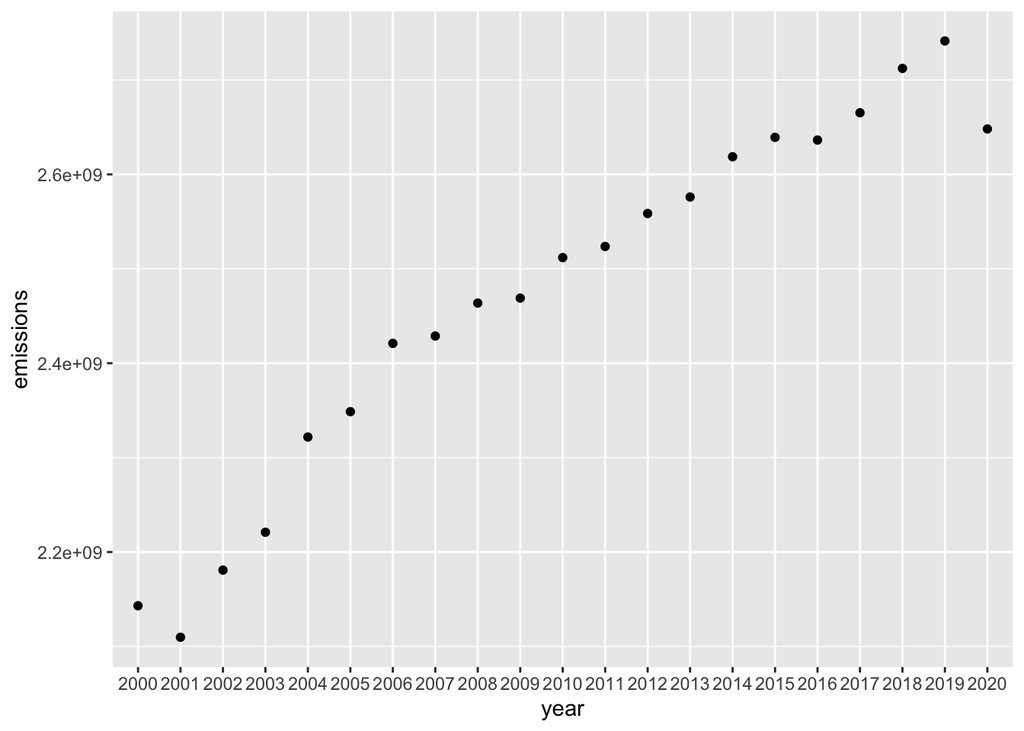

```r
#rename columns
yearly_emissions <-
yearly_emissions %>%
  rename(
    year = Group.1,
    emissions = x
    )

ggplot(yearly_emissions, aes(x = year, y = emissions)) +
  geom_point()
```

#### Total emissions per country

```r
emissions_by_area <- aggregate(df_longer$'total emissions', by = list(df_longer$Area), FUN = sum)

#rename columns
emissions_by_area <-
emissions_by_area %>%
  rename(
    country = Group.1,
    emissions = x
    )

top <- emissions_by_area[order(-emissions_by_area$emissions),]

print(head(df))
```

```
##          Area             Item                          Element       Unit
## 1 Afghanistan    Crop Residues           Direct emissions (N2O) kilotonnes
## 2 Afghanistan    Crop Residues         Indirect emissions (N2O) kilotonnes
## 3 Afghanistan    Crop Residues                  Emissions (N2O) kilotonnes
## 4 Afghanistan    Crop Residues Emissions (CO2eq) from N2O (AR5) kilotonnes
## 5 Afghanistan    Crop Residues          Emissions (CO2eq) (AR5) kilotonnes
## 6 Afghanistan Rice Cultivation                  Emissions (CH4) kilotonnes
##      2000     2001     2002     2003     2004     2005     2006     2007
## 1   0.520   0.5267   0.8200   0.9988   0.8225   1.1821   1.0277   1.2426
## 2   0.117   0.1185   0.1845   0.2247   0.1851   0.2660   0.2312   0.2796
## 3   0.637   0.6452   1.0045   1.2235   1.0075   1.4481   1.2589   1.5222
## 4 168.807 170.9884 266.1975 324.2195 266.9995 383.7498 333.6093 403.3749
## 5 168.807 170.9884 266.1975 324.2195 266.9995 383.7498 333.6093 403.3749
## 6  18.200  16.9400  18.9000  20.3000  27.3000  22.4000  22.4000  23.8000
##       2008     2009     2010     2011     2012     2013     2014     2015
## 1   0.8869   1.3920   1.2742   1.0321   1.3726   1.4018   1.4584   1.2424
## 2   0.1996   0.3132   0.2867   0.2322   0.3088   0.3154   0.3281   0.2795
## 3   1.0865   1.7051   1.5609   1.2643   1.6815   1.7173   1.7865   1.5220
## 4 287.9099 451.8647 413.6467 335.0379 445.5958 455.0727 473.4174 403.3181
## 5 287.9099 451.8647 413.6467 335.0379 445.5958 455.0727 473.4174 403.3181
## 6  26.6000  28.0000  29.1200  29.4000  28.7000  28.7000  30.8000  22.9600
##       2016     2017     2018     2019     2020
## 1   1.1940   1.0617   0.8988   1.2176   1.3170
## 2   0.2687   0.2389   0.2022   0.2740   0.2963
## 3   1.4627   1.3005   1.1011   1.4916   1.6133
## 4 387.6130 344.6447 291.7838 395.2689 427.5284
## 5 387.6130 344.6447 291.7838 395.2689 427.5284
## 6  16.6600  15.3233  16.4555  17.8542  20.6577
```

#### Analysis of Total emissions per country

too many countries, cant read

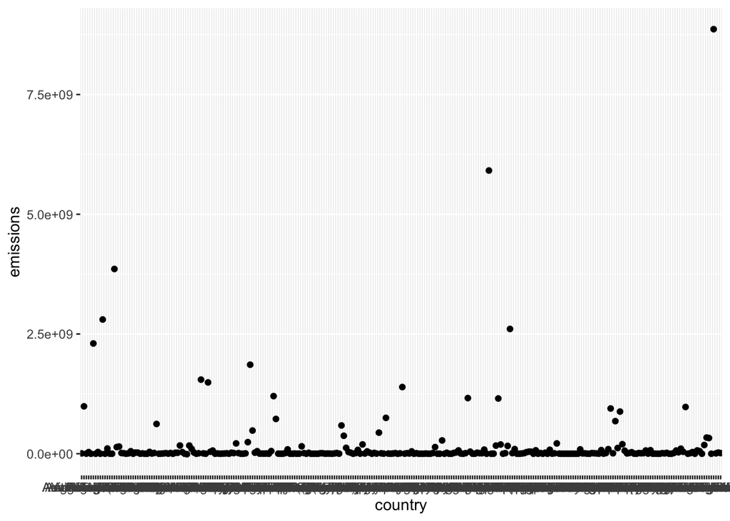

```r
ggplot(emissions_by_area, aes(x = country, y = emissions), label=NA)+ geom_point()
```

#### Aanalyze by emission type

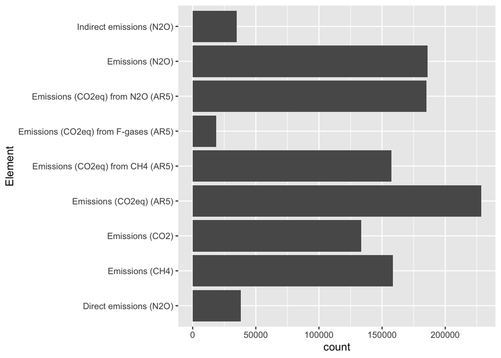

```r
ggplot(df_longer, aes(y=Element)) +
         geom_bar()
```

#### USA emission types distribution

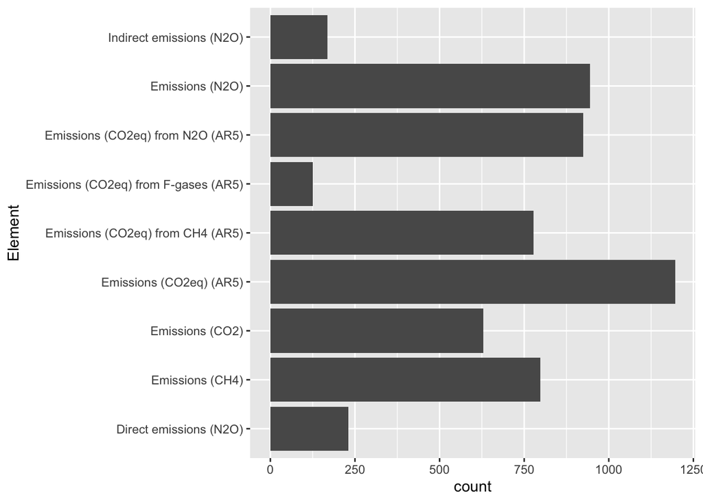

```r
usa <- df_longer %>%
  filter(Area == "United States of America")

ggplot(usa, aes(y=Element)) +
         geom_bar()
```

#### Item Analysis

Highest item is IPCC Agriculture. Second highest is farm gate emissions. Lowest is international bunkers.

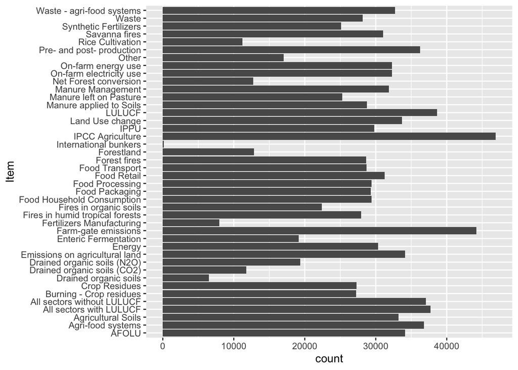

```r
ggplot(df_longer, aes(y=Item)) +
         geom_bar()
```

#### Item Analysis USA

Highest item is IPCC Agriculture, just like in the overall data. Lowest is drained organic soils (C02) and drained organic soils.

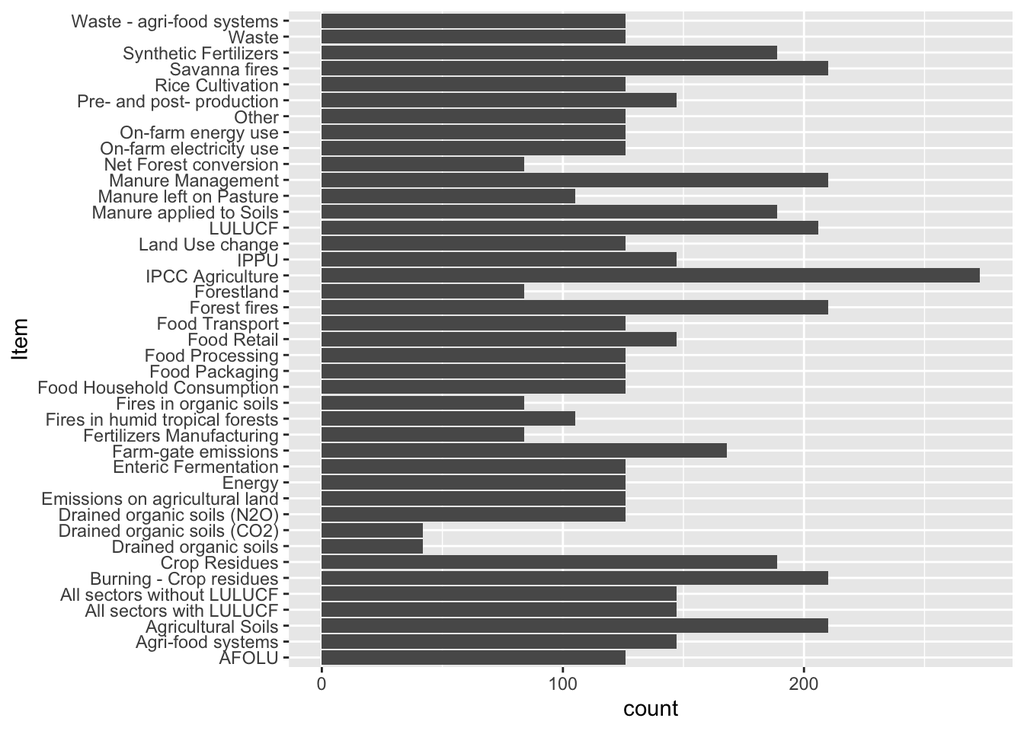

```r
ggplot(usa, aes(y=Item)) +
         geom_bar()
```

## **NYSDEC Water Permit Data (DART):**

#### Loading NYSDEC DART Data

Data used in this section comes from [New York State Department of Environmental Conservation’s Application Review & Tracking System (DART on the Web)](https://extapps.dec.ny.gov/cfmx/extapps/envapps/index.cfm).

DART is a web-based application and tracking system that is designed for the general public. DART hosts information about NYSDEC’s processing and issuance of environmental permits under the Uniform Procedures Act. The data is updated daily, and more information about the data can be found in the [data dictionary](https://dev.socrata.com/foundry/data.ny.gov/mbk7-f2r2).

In this section, data was previously filtered to only include DART entries from 2020-2025, and will be focused on waste water permits that discharge to surface water.

```r
library(readr)
dart <- read_csv("https://raw.githubusercontent.com/AlinaVikhnevich/data_607/refs/heads/main/Project%202/dart_2020_2025.csv")
```

#### Defining Regex Patterns to Detect NPDES IDs

To identify wastewater permits, there are three regex patterns to identify:

1. NPDES Permit (meaning a regular permit).
2. General Permit
3. Individual Permit (these are permits that are processed under general permits).

For more information about permit types please see the question “What are the primary differences between a NODES individual permit and a NPDES general permit” under [EPA’s NPDES Permit Basics Site](https://www.epa.gov/npdes/npdes-permit-basics).

```r
# p_type = permit type, in this exercise we are filtering for wastewater permits
p_type <- c("P/C/I SPDES - Surface Discharge",
            "Municipal SPDES - Surface Discharge",
            "Industrial SPDES - Surface Discharge")

# defining the regex patterns for the IDs we want to track
npdes_pattern <- "NY\\d{7}"
gp_pattern <- "GP\\d{7}"
individual_pattern <- "NY[A-Z]\\d{2}[A-Z]\\d{3}"
all_patterns <- paste(npdes_pattern,gp_pattern,individual_pattern, sep="|")
```

#### Creating the NPDES Universe

Creating the permit universe pulling from NYSDEC’s DART System and detecting the string patterns within DART to assign permit type: npdes, individual(i.e., a permit covered under a general permit), general, or multi (meaning the DART entry had multiple associated IDs).

```r
universe <- dart |>
  filter(`permit_type` %in% p_type) |>
  mutate(
    npdes = str_count(`other_known_ids`, npdes_pattern), # the str_counts are taking count of permit ID type
    individual = str_count(`other_known_ids`, individual_pattern),
    gp =  str_count(`other_known_ids`, gp_pattern),
    sum_ids = rowSums(across(c(`npdes`, `individual`,`gp`))),
    npdes_id = str_extract_all(`other_known_ids`, all_patterns),
    date_received=as.Date(date_received, format = "%d-%m-%Y")
    ) |>
  mutate(applicant_id =cur_group_id(),.by = applicant) |> # creating applicant id
  mutate(facility_id = cur_group_id(),.by = c(facility,location,town_or_city)) |> # creating facility id
  distinct() |> # removing duplicate rows
  mutate(
          dart_p_type = case_when(sum_ids  > 1 ~ "multi", # if entry is associated with multiple ids, it is flagged as multi
                               sum_ids & npdes == 1 ~ "npdes",
                               sum_ids & individual == 1 ~ "individual",
                               sum_ids & gp == 1 ~ "gp")) |>
  unnest_longer(npdes_id, keep_empty = FALSE) |>
  filter(!is.na(npdes_id))
```

Note: The code above filters entries that did not have a NPDES ID listed in the “Other Known IDs” column, however, were listed as NPDES permits in the Permit Type Column. However, out of 35,642 entries, only 69 were missing NPDES IDs.

#### Table 1: Permit Level Data

This table shows the most recent permit information

```r
tbl1_permit_lvl <- universe  |>
  group_by(npdes_id) |>
  slice(which.max(date_received)) |>
  select(npdes_id,facility_id,application_id,applicant,applicant_id,permit_type,
         status,date_received,upa_class,seqr_class,seqr_determination,
         lead_agency,coastal_zone_status, final_disposition,permit_effective_date,
         permit_expration_date,dec_contact,shpa_status,enivronmental_justice)
```

Permit Data Head

| npdes_id | facility_id | application_id | applicant | applicant_id | permit_type | status | date_received | upa_class | seqr_class | seqr_determination | lead_agency | coastal_zone_status | final_disposition | permit_effective_date | permit_expration_date | dec_contact | shpa_status | enivronmental_justice |
| --- | --- | --- | --- | --- | --- | --- | --- | --- | --- | --- | --- | --- | --- | --- | --- | --- | --- | --- |
| NY0000044 | 574 | 3-3724-00045/00004 | WATCHTOWER BIBLE AND TRACT SOCIETY OF NEW YORK INC | 158 | P/C/I SPDES - Surface Discharge | Issued | 2024-02-16 | MINOR | Type II Action | Not Applicable | None Designated | This project is not located in a Coastal Management area. | Issued | 2024-09-01 04:00:00 | 2029-08-31 04:00:00 | KATHERINE M MURRAY | NA | NA |
| NY0000078 | 706 | 8-5436-00007/00014 | GARLOCK SEALING TECHNOLOGIES LLC | 593 | Industrial SPDES - Surface Discharge | SAPA Extended | 2021-02-03 | MAJOR | Type II Action | Not Applicable | None Designated | This project is not located in a Coastal Management area. | Issued | 2023-07-01 04:00:00 | 2023-08-31 04:00:00 | GUILLERMO R SAAR | NA | The application is subject to the Department Environmental Justice policy (CP-29). Either the permits needed for the project are not subject to the policy or it has been determined that the project wo… |
| NY0000167 | 1906 | 8-2499-00039/00002 | RETSOF REALTY LLC | 1571 | Industrial SPDES - Surface Discharge | Issued | 2021-04-15 | MINOR | Type II Action | Not Applicable | None Designated | This project is not located in a Coastal Management area. | Issued | 2022-01-01 05:00:00 | 2026-12-31 05:00:00 | MICHAEL R SCHAEFER | NA | NA |
| NY0000247 | 1556 | 3-5518-00680/00001 | CONSOLIDATED EDISON COMPANY OF NEW YORK, INC. | 914 | Industrial SPDES - Surface Discharge | Suspended Indefinitely | 2024-04-22 | MINOR | Type II Action | Not Applicable | None Designated | This project is not located in a Coastal Management area. | NA | NA | NA | KATHERINE M MURRAY | NA | NA |
| NY0000281 | 539 | 9-1464-00117/00013 | LINDE INC | 455 | Industrial SPDES - Surface Discharge | Issued | 2021-04-29 | MINOR | Type II Action | Not Applicable | None Designated | This project is not located in a Coastal Management area. | Issued | 2022-01-11 05:00:00 | 2026-12-31 05:00:00 | MICHAEL R SCHAEFER | NA | NA |
| NY0000311 | 1420 | 8-3224-00108/00031 | PACTIV LLC | 1186 | Industrial SPDES - Surface Discharge | Issued | 2021-08-02 | MINOR | Type II Action | Not Applicable | None Designated | This project is not located in a Coastal Management area. | Issued | 2022-03-01 05:00:00 | 2027-02-28 05:00:00 | MICHAEL R SCHAEFER | NA | NA |

#### Table 2: Permit Action Level Data

This table shows the permit history. each observation in this table represents a permit action.

```r
tbl2_permit_act_lvl <- universe |>
    mutate(action_id = paste(npdes_id,date_received, sep = "_")) |>
    distinct() |>
    mutate(dup_flag = duplicated(action_id),
           transfer_flag=str_detect(toupper(short_description),"TRANSFER")) |>
  select(action_id,facility,facility_id,npdes_id,application_id,applicant,
         application_type,date_received,status,short_description,
         enb_publication_date,written_comments_due,dup_flag,transfer_flag)

tbl2_permit_act_lvl$short_description <- tolower(tbl2_permit_act_lvl$short_description)
```

Permit Action Data Head

| action_id | facility | facility_id | npdes_id | application_id | applicant | application_type | date_received | status | short_description | enb_publication_date | written_comments_due | dup_flag | transfer_flag |
| --- | --- | --- | --- | --- | --- | --- | --- | --- | --- | --- | --- | --- | --- |
| NY0101915_2022-10-05 | B O C E S | 1 | NY0101915 | 3-1332-00172/00001 | DUTCHESS BOCES | Renewal Treat as New | 2022-10-05 | Issued | spdes fast track renewal for ny0101915 | 2023-02-15 05:00:00 | 2023-03-17 04:00:00 | FALSE | FALSE |
| NYR10L635_2023-03-24 | NYC EDC-SOUTH BROOKLYN MARINE TERMINAL | 2 | NYR10L635 | 2-6102-00120/00032 | NYC ECONOMIC DEVELOPMENT CORP | New | 2023-03-24 | Issued | spdes application for substation test pits and construction | 2024-03-20 04:00:00 | 2024-04-19 04:00:00 | FALSE | FALSE |
| NY0313149_2023-03-24 | NYC EDC-SOUTH BROOKLYN MARINE TERMINAL | 2 | NY0313149 | 2-6102-00120/00032 | NYC ECONOMIC DEVELOPMENT CORP | New | 2023-03-24 | Issued | spdes application for substation test pits and construction | 2024-03-20 04:00:00 | 2024-04-19 04:00:00 | FALSE | FALSE |
| NY0035441_2021-06-30 | CHAUTAUQUA FISH HATCHERY | 3 | NY0035441 | 9-0628-00098/00004 | NYS Dept of Environmental Conservation | New | 2021-06-30 | Issued | reduce conc. limit of formalin & change in phos. loading limit | 2021-09-29 04:00:00 | 2021-10-29 04:00:00 | FALSE | FALSE |
| NY0071897_2021-03-30 | EFFRON FUEL OIL CORP TERMINAL | 4 | NY0071897 | 3-1313-00015/00002 | PETRO INC | Minor Modification | 2021-03-30 | Expired | transfer | NA | NA | FALSE | TRUE |
| NY0071897_2022-09-08 | EFFRON FUEL OIL CORP TERMINAL | 4 | NY0071897 | 3-1313-00015/00002 | PETRO INC | Renewal Treat as New | 2022-09-08 | Issued | spdes fast track renewal for ny 0071897 | 2022-11-02 04:00:00 | 2022-12-02 05:00:00 | FALSE | FALSE |

#### Table 3: Facility Level Data

This table shows the facility information. Each observation in this table represents a facility associated with NPDES permits.

```r
tbl3_facility_lvl <- universe |>
  select(facility_id,facility,
         location,town_or_city) |>
  distinct() |>
  arrange(facility_id)
```

Facility Data Head

| facility_id | facility | location | town_or_city |
| --- | --- | --- | --- |
| 1 | B O C E S | 578 SALT POINT TURNPIKE HYDE PARK 12538 | HYDE PARK |
| 2 | NYC EDC-SOUTH BROOKLYN MARINE TERMINAL | Sunset Park and Greenwood Heights 29th to 39th St\|2nd Ave To Ny Harbor Brooklyn (6102) 11232 | BROOKLYN |
| 3 | CHAUTAUQUA FISH HATCHERY | 5875 PRENDERGAST RD MAYVILLE 14757 | CHAUTAUQUA |
| 4 | EFFRON FUEL OIL CORP TERMINAL | FOOT OF PROSPECT ST POUGHKEEPSIE 12602 | POUGHKEEPSIE |
| 5 | POUGHKEEPSIE STP | 173 KITTREDGE PL POUGHKEEPSIE 12601 | POUGHKEEPSIE |
| 6 | AMENIA S & G-LEEDSVILLE PROCESSING PLANT | 307 LEEDSVILLE RD AMENIA 12501 | AMENIA |

#### Table 4: NPDES Permit Applicant Table

This table shows the applicant information. Each observation in this table represents a permit applicant for NPDES permits.

```r
tbl4_app_lvl <- universe |>
  group_by(applicant_id) |>
  slice(which.max(date_received)) |>
  select(applicant_id,applicant,application_id)
```

NPDES Permit Applicant Data Head

| applicant_id | applicant | application_id |
| --- | --- | --- |
| 1 | DUTCHESS BOCES | 3-1332-00172/00001 |
| 2 | NYC ECONOMIC DEVELOPMENT CORP | 2-6402-00004/00100 |
| 3 | NYS Dept of Environmental Conservation | 3-4844-00112/00001 |
| 4 | PETRO INC | 3-1334-00136/00001 |
| 5 | CITY OF POUGHKEEPSIE | 3-1346-00364/00003 |
| 6 | DOLOMITE PRODUCTS COMPANY INC. | 8-1836-00001/02002 |

#### Data Tables and Structure

```
(1) Table 1 - permit table: the purpose of this table is to have the most
recent permit information. This will have one row per permit.

(2) Table 2 - permit action table: the purpose of this table is to have a
table with every permit-action. This means there should be one row per
permit action.

(3) Table 3 - facility table: the purpose of this table is to have
information on the facility.

(4) Table 4 - applicant table: the purpose of this table is to have
information about the applicant.
```

#### Data Considerations:

- There was missing data, such as NPDES IDs. This means that some permit information may not be available.
- There may be facilities that are listed as different facilities due to address changes. This information should be verified. Databases like [EPA’s Enforcement and Compliance History Online (ECHO)](https://echo.epa.gov/)) may be helpful for verifying facility information.
- For entries that were made on the same day for a particular permit, it is not possible to identify which entry was made first. Permit transfer actions are largely affected by this. Due to this, duplicates and transfers are flagged for manual review.

#### Analysis

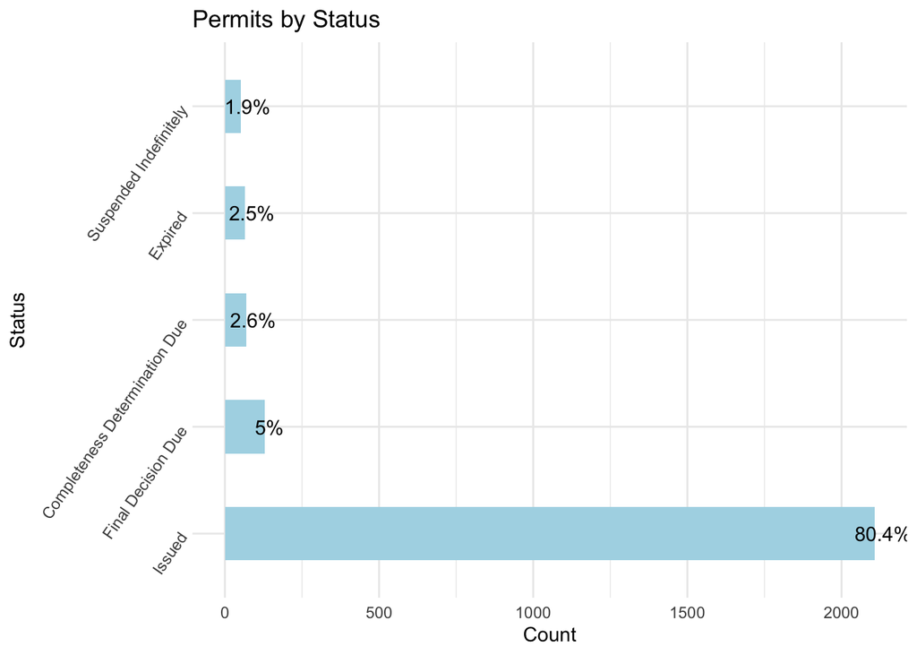

```r
permit_status <- tbl1_permit_lvl |>
group_by(status) |>
  summarize(
    Count = n(),
    Proportion = (n()/nrow(tbl1_permit_lvl))*100
  ) |>
  arrange(desc(Proportion)) |>
  head(5) |>
  rename("Status" = "status")

permit_status$Proportion <- paste0(round(permit_status$Proportion, digits=1),"%")

ggplot(permit_status,aes(x = reorder(Status, -Count), y= Count)) +
    geom_bar(stat="identity", fill="lightblue", width=0.5)+
    geom_text(aes(label=Proportion),
              hjust=.35)+
    theme_minimal()+
    labs(title="Permits by Status",x="Status")+
    theme(axis.text.y =element_text(angle = 55,hjust=1))+
    coord_flip()
```

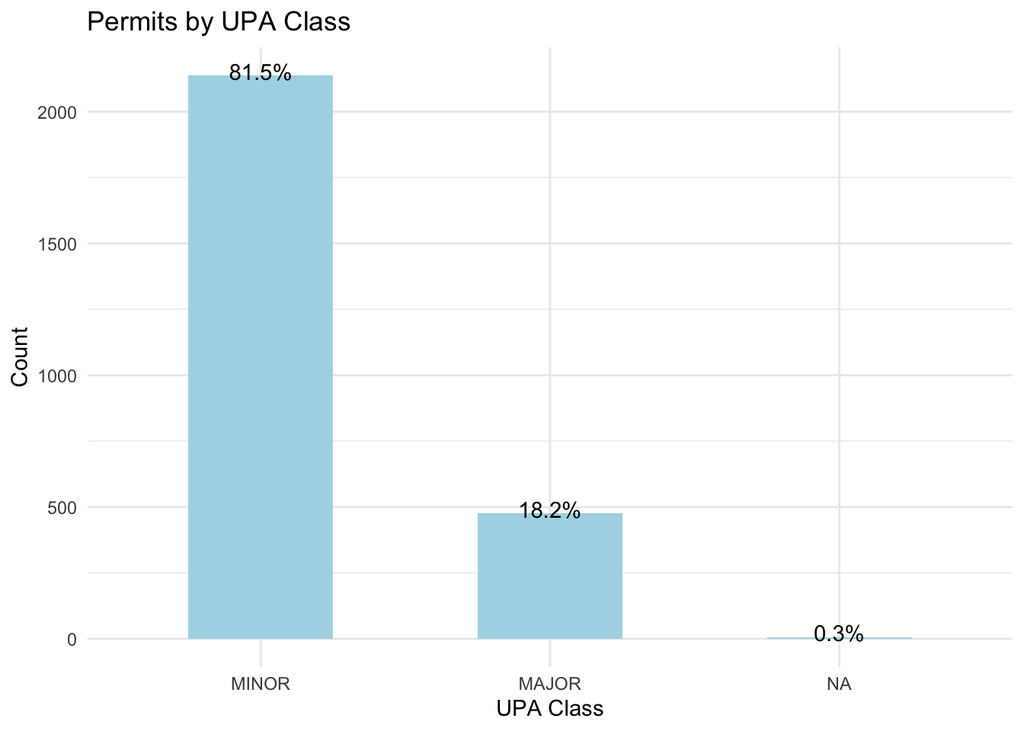

```r
upa_class <- tbl1_permit_lvl |>
group_by(upa_class) |>
  summarize(
    Count = n(),
    Proportion = (n()/nrow(tbl1_permit_lvl))*100
  )

upa_class$Proportion <- paste0(round(upa_class$Proportion, digits=1),"%")

ggplot(upa_class,aes(x = reorder(upa_class, -Count), y= Count)) +
    geom_bar(stat="identity", fill="lightblue", width=0.5)+
    geom_text(aes(label=Proportion),
              hjust=.5,
              vjust=0.25)+
    theme_minimal()+
    labs(title="Permits by UPA Class",x="UPA Class")
```

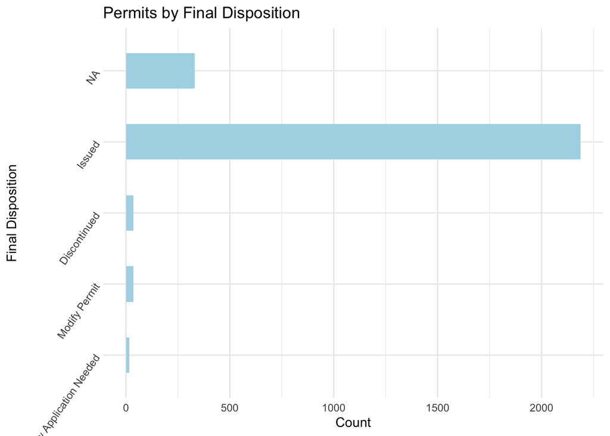

```r
final_dis <- tbl1_permit_lvl |>
group_by(final_disposition) |>
  summarize(
    Count = n(),
    Proportion = (n()/nrow(tbl1_permit_lvl))*100
  ) |>
  arrange(desc(Count)) |>
  head(5)

final_dis$Proportion <- paste0(round(final_dis$Proportion, digits=1),"%")
final_dis$Count <- as.numeric(final_dis$Count)

final_dis <- final_dis |>
  clean_names("title")

ggplot(final_dis,aes(x =reorder(`Final Disposition`,`Count`, .desc = TRUE), y= Count)) +
    geom_bar(stat="identity", fill="lightblue", width=0.5)+
    theme_minimal()+
    labs(title="Permits by Final Disposition",x="Final Disposition")+
    theme(axis.text.y =element_text(angle = 55,hjust=1))+
    coord_flip()
```

```r
app_type <- tbl2_permit_act_lvl |>
group_by(application_type) |>
  summarize(
    Count = n(),
    Proportion = n()/nrow(tbl2_permit_act_lvl)
  ) |>
  clean_names("title") |>
  arrange(desc(Count))

knitr::kable(app_type, format ="markdown")
```

| Application Type | Count | Proportion |
| --- | --- | --- |
| Renewal Treat as New | 2565 | 0.7753930 |
| Modification Treat as New | 274 | 0.0828295 |
| Minor Modification | 185 | 0.0559250 |
| New | 160 | 0.0483676 |
| Modification | 48 | 0.0145103 |
| DIM Treat as New | 47 | 0.0142080 |
| Department Initiated Modification | 29 | 0.0087666 |

```r
short_desc <- tbl2_permit_act_lvl |>
  mutate(c_fast_track=coalesce(str_count(short_description,"fast track"),0)) |>
  summarize(
    "Fast Tracked Renewal Actions" = sum(c_fast_track),
    "Total Actions" = nrow(tbl2_permit_act_lvl),
    Proportion = sum(c_fast_track)/nrow(tbl2_permit_act_lvl)
  ) |>
  clean_names("title")

knitr::kable(short_desc, format ="markdown")
```

| Fast Tracked Renewal Actions | Total Actions | Proportion |
| --- | --- | --- |
| 2204 | 3308 | 0.6662636 |

## **Cheese Dataset:**

#### Import Data

Read in raw csv file as data frame

```r
data <- read.csv("https://raw.githubusercontent.com/rfordatascience/tidytuesday/refs/heads/main/data/2024/2024-06-04/cheeses.csv")
```

##### View Raw Data

Raw Data Head

| cheese | url | milk | country | region | family | type | fat_content | calcium_content | texture | rind | color | flavor | aroma | vegetarian | vegan | synonyms | alt_spellings | producers |
| --- | --- | --- | --- | --- | --- | --- | --- | --- | --- | --- | --- | --- | --- | --- | --- | --- | --- | --- |
| Aarewasser | https://www.cheese.com/aarewasser/ | cow | Switzerland | NA | NA | semi-soft | NA | NA | buttery | washed | yellow | sweet | buttery | FALSE | FALSE | NA | NA | Jumi |
| Abbaye de Belloc | https://www.cheese.com/abbaye-de-belloc/ | sheep | France | Pays Basque | NA | semi-hard, artisan | NA | NA | creamy, dense, firm | natural | yellow | burnt caramel | lanoline | TRUE | FALSE | Abbaye Notre-Dame de Belloc | NA | NA |
| Abbaye de Belval | https://www.cheese.com/abbaye-de-belval/ | cow | France | NA | NA | semi-hard | 40-46% | NA | elastic | washed | ivory | NA | aromatic | FALSE | FALSE | NA | NA | NA |
| Abbaye de Citeaux | https://www.cheese.com/abbaye-de-citeaux/ | cow | France | Burgundy | NA | semi-soft, artisan, brined | NA | NA | creamy, dense, smooth | washed | white | acidic, milky, smooth | barnyardy, earthy | FALSE | FALSE | NA | NA | NA |
| Abbaye de Tamié | https://www.cheese.com/tamie/ | cow | France | Savoie | NA | soft, artisan | NA | NA | creamy, open, smooth | washed | white | fruity, nutty | perfumed, pungent | FALSE | FALSE | NA | Tamié, Trappiste de Tamie, Abbey of Tamie | NA |
| Abbaye de Timadeuc | https://www.cheese.com/abbaye-de-timadeuc/ | cow | France | province of Brittany | NA | semi-hard | NA | NA | soft | washed | pale yellow | salty, smooth | nutty | FALSE | FALSE | NA | NA | Abbaye Cistercienne NOTRE-DAME DE TIMADEUC |

Raw Data Stats

| Row_Count | Column_Count | Null_Count | None_Str_Count |
| --- | --- | --- | --- |
| 1187 | 19 | 7133 | 0 |

#### Data Handling

- select columns needed to tidy and for analysis
- fill empty strings and null values with ‘None’ string

```r
fill_empty_str = function(x){if_else(x=="", 'None' ,x)}

df = data |>
  select(cheese, milk, country, texture, aroma, flavor) |>
  mutate_all(fill_empty_str) |>
  mutate_all(replace_na, "None")
```

Data after Handling Stats

| Row_Count | Column_Count | Null_Count | None_Str_Count |
| --- | --- | --- | --- |
| 1187 | 6 | 0 | 340 |

#### Tidy Data

Tidy data by ensuring each value has its own cell

- split out each row with listed values (milk, texture, aroma, flavor, country) into individual rows and lengthen the data frame

```r
df = df |>
  mutate(cheese_id = row_number()) |>
  separate_rows(country, sep = ', ') |>
  separate_rows(milk, sep = ', ') |>
  separate_rows(texture, sep = ', ') |>
  separate_rows(aroma, sep = ', ') |>
  separate_rows(flavor, sep = ', ')
```

##### View Tidy Data

Tidy Data Head

| cheese | milk | country | texture | aroma | flavor | cheese_id |
| --- | --- | --- | --- | --- | --- | --- |
| Aarewasser | cow | Switzerland | buttery | buttery | sweet | 1 |
| Abbaye de Belloc | sheep | France | creamy | lanoline | burnt caramel | 2 |
| Abbaye de Belloc | sheep | France | dense | lanoline | burnt caramel | 2 |
| Abbaye de Belloc | sheep | France | firm | lanoline | burnt caramel | 2 |
| Abbaye de Belval | cow | France | elastic | aromatic | None | 3 |
| Abbaye de Citeaux | cow | France | creamy | barnyardy | acidic | 4 |

Tidy Data Stats

| Row_Count | Column_Count | Null_Count | None_Str_Count |
| --- | --- | --- | --- |
| 14394 | 7 | 0 | 2050 |

#### Normalize Data

Normalize data to reduce redundancy and allow for more efficient analysis

- create a data frame for each column and create an associated id column for each
- replace all column values with respective id value in core data frame

```r
create_id_dfs = function(id_prefix, col, df) {
  id_df = df |>
    select(all_of(col)) |>
    distinct() |>
    arrange(col) |>
    mutate(id = paste0(id_prefix, row_number()))
  return(id_df)
}

cheese_df = df |>
  select(cheese, cheese_id) |>
  distinct()

country_df = create_id_dfs('C', 'country', df)
colnames(country_df) = c('country', 'country_id')

milk_df = create_id_dfs('M', 'milk', df)
colnames(milk_df) = c('milk', 'milk_id')

texture_df = create_id_dfs('T', 'texture', df)
colnames(texture_df) = c('texture', 'texture_id')

aroma_df = create_id_dfs('A', 'aroma', df)
colnames(aroma_df) = c('aroma', 'aroma_id')

flavor_df = create_id_dfs('F', 'flavor', df)
colnames(flavor_df) = c('flavor', 'flavor_id')

df = left_join(df, country_df, by = join_by(country))
df = left_join(df, milk_df, by = join_by(milk))
df = left_join(df, texture_df, by = join_by(texture))
df = left_join(df, aroma_df, by = join_by(aroma))
df = left_join(df, flavor_df, by = join_by(flavor))

df = df |>
  select(cheese_id, country_id, milk_id, texture_id, aroma_id, flavor_id)
```

##### View Tidy and Normalized Data

Normalized Tidy Data Head

| cheese_id | country_id | milk_id | texture_id | aroma_id | flavor_id |
| --- | --- | --- | --- | --- | --- |
| 1 | C1 | M1 | T1 | A1 | F1 |
| 2 | C2 | M2 | T2 | A2 | F2 |
| 2 | C2 | M2 | T3 | A2 | F2 |
| 2 | C2 | M2 | T4 | A2 | F2 |
| 3 | C2 | M1 | T5 | A3 | F3 |
| 4 | C2 | M1 | T2 | A4 | F4 |

Cheese Table Head

| cheese | cheese_id |
| --- | --- |
| Aarewasser | 1 |
| Abbaye de Belloc | 2 |
| Abbaye de Belval | 3 |
| Abbaye de Citeaux | 4 |
| Abbaye de Tamié | 5 |
| Abbaye de Timadeuc | 6 |

Country Table Head

| country | country_id |
| --- | --- |
| Switzerland | C1 |
| France | C2 |
| England | C3 |
| Great Britain | C4 |
| United Kingdom | C5 |
| Czech Republic | C6 |

Milk Table Head

| milk | milk_id |
| --- | --- |
| cow | M1 |
| sheep | M2 |
| goat | M3 |
| buffalo | M4 |
| None | M5 |
| water buffalo | M6 |

Texture Table Head

| texture | texture_id |
| --- | --- |
| buttery | T1 |
| creamy | T2 |
| dense | T3 |
| firm | T4 |
| elastic | T5 |
| smooth | T6 |

Aroma Table Head

| aroma | aroma_id |
| --- | --- |
| buttery | A1 |
| lanoline | A2 |
| aromatic | A3 |
| barnyardy | A4 |
| earthy | A5 |
| perfumed | A6 |

Flavor Table Head

| flavor | flavor_id |
| --- | --- |
| sweet | F1 |
| burnt caramel | F2 |
| None | F3 |
| acidic | F4 |
| milky | F5 |
| smooth | F6 |

#### Analysis

**Analysis Requested in Discussion Post:**

1. What are the most common milks used?
2. What are the more common textures associated with cheese?
3. Is there a country or region that produces more cheese?
4. Are there common aromas or flavors across cheeses made by different milks?

##### 1. Most Common Milks Used

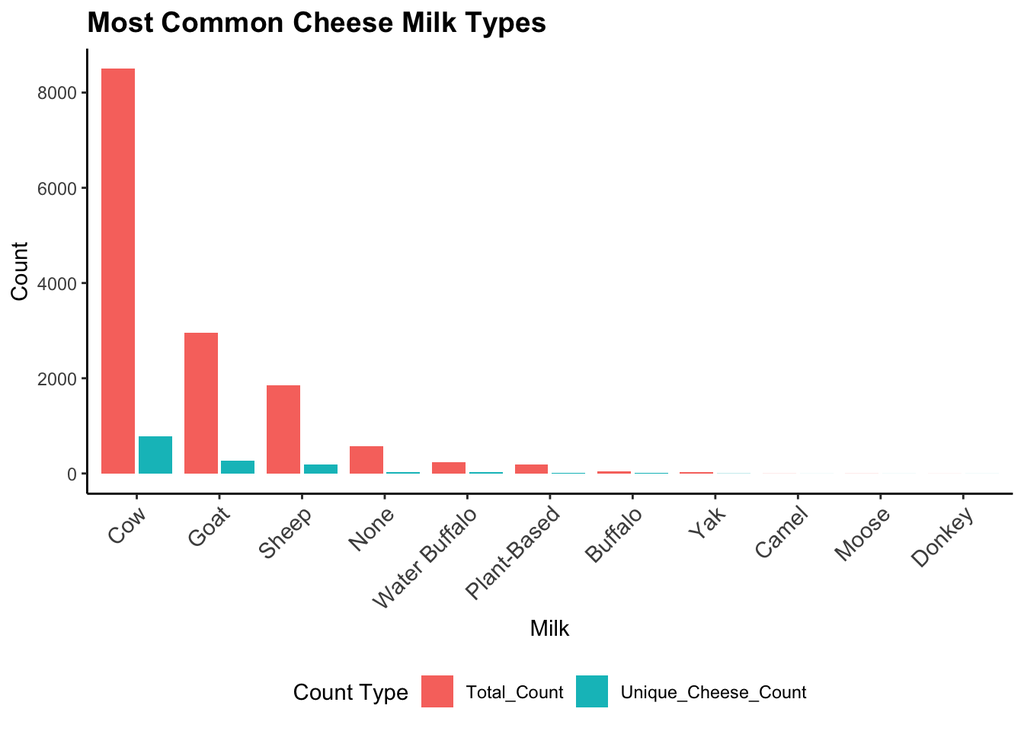

```r
df |>
  select(cheese_id, milk_id) |>
  left_join(cheese_df, by = join_by(cheese_id)) |>
  left_join(milk_df, by = join_by(milk_id)) |>
  mutate(milk = str_to_title(milk)) |>
  group_by(milk) |>
  summarise(
    Total_Count = n(),
    Unique_Cheese_Count = n_distinct(cheese)) |>
  pivot_longer(cols = c(Total_Count, Unique_Cheese_Count)) |>
  ggplot(aes(x = reorder(milk, -value), y = value, fill = name)) +
  geom_col(position = position_dodge2(width = 0.3, preserve = "single")) +
  labs(
    title = "Most Common Cheese Milk Types",
    x = "Milk",
    y = "Count",
    fill = 'Count Type'
  ) +
  theme_classic() +
  theme(
    axis.text.x = element_text(size = 11, angle = 45, vjust = 1, hjust=1),
    plot.title = element_text(size = 14, face = "bold"),
    legend.position = "bottom")
```

##### 2. Most Common Textures Associated with Cheeses

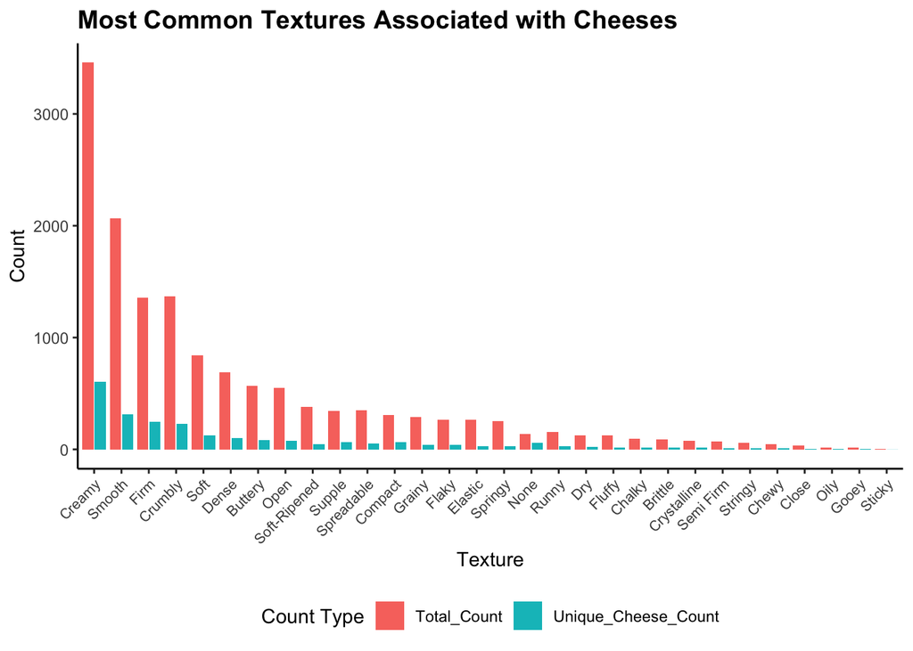

```r
df |>
  select(cheese_id, texture_id) |>
  left_join(cheese_df, by = join_by(cheese_id)) |>
  left_join(texture_df, by = join_by(texture_id)) |>
  mutate(texture = str_to_title(texture)) |>
  group_by(texture) |>
  summarise(
    Total_Count = n(),
    Unique_Cheese_Count = n_distinct(cheese)) |>
  pivot_longer(cols = c(Total_Count, Unique_Cheese_Count)) |>
  ggplot(aes(x = reorder(texture, -value), y = value, fill = name)) +
  geom_col(position = position_dodge2(width = 0.2, preserve = "single")) +
  labs(
    title = "Most Common Textures Associated with Cheeses",
    x = "Texture",
    y = "Count",
    fill = 'Count Type'
  ) +
  theme_classic() +
  theme(
    axis.text.x = element_text(angle = 45, vjust = 1, hjust=1, size = 8),
    plot.title = element_text(size = 14, face = "bold"),
    legend.position = "bottom")
```

##### 3. Countries Producing Most Cheese

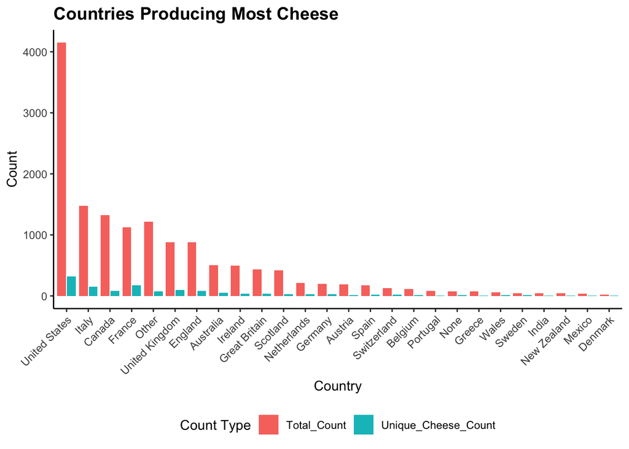

```r
df |>
  select(cheese_id, country_id) |>
  left_join(cheese_df, by = join_by(cheese_id)) |>
  left_join(country_df, by = join_by(country_id)) |>
  mutate(country = str_to_title(country)) |>
  group_by(country) |>
  summarise(
    Total_Count = n(),
    Unique_Cheese_Count = n_distinct(cheese)) |>
  mutate(country = ifelse(Unique_Cheese_Count <= 5, 'Other', country)) |>
  group_by(country) |>
  summarise(
    Total_Count = sum(Total_Count),
    Unique_Cheese_Count = sum(Unique_Cheese_Count)) |>
  pivot_longer(cols = c(Total_Count, Unique_Cheese_Count)) |>
  ggplot(aes(x = reorder(country, -value), y = value, fill = name)) +
  geom_col(position = position_dodge2(width = 0.2, preserve = "single")) +
  labs(
    title = "Countries Producing Most Cheese",
    x = "Country",
    y = "Count",
    fill = 'Count Type'
  ) +
  theme_classic() +
  theme(
    axis.text.x = element_text(angle = 45, vjust = 1, hjust=1),
    plot.title = element_text(size = 14, face = "bold"),
    legend.position = "bottom")
```

##### 4a. Common Flavors Across Cheeses By Different Milks

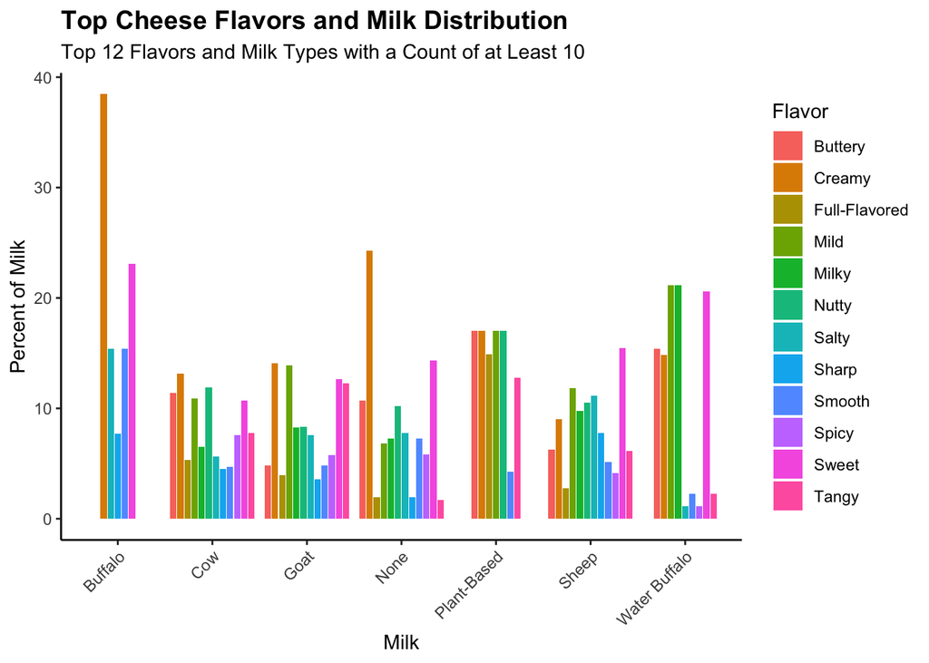

```r
top_flavor_df = df |>
  left_join(cheese_df, by = join_by(cheese_id)) |>
  left_join(flavor_df, by = join_by(flavor_id)) |>
  group_by(flavor, flavor_id) |>
  summarise(cnt = n(), .groups = 'keep') |>
  arrange(desc(cnt)) |>
  head(12)

milk_cnt_df = df |>
  left_join(cheese_df, by = join_by(cheese_id)) |>
  inner_join(top_flavor_df, by = join_by(flavor_id)) |>
  left_join(milk_df, by = join_by(milk_id)) |>
  group_by(milk, milk_id) |>
  summarise(milk_cnt = n(), .groups = 'keep') |>
  filter(milk_cnt>10)

df |>
  select(cheese_id, milk_id, flavor_id) |>
  left_join(cheese_df, by = join_by(cheese_id)) |>
  inner_join(top_flavor_df, by = join_by(flavor_id)) |>
  inner_join(milk_cnt_df, by = join_by(milk_id)) |>
  mutate(
    flavor = str_to_title(flavor),
    milk = str_to_title(milk)
    ) |>
  group_by(milk) |>
  mutate(y= n()) |>
  group_by(milk, flavor) |>
  mutate(x = n()) |>
  mutate(Unique_Cheese_Prct =  (x / y)*100) |>
  select(milk, flavor, Unique_Cheese_Prct, x, milk_cnt, y) |>
  distinct() |>
  ggplot(aes(x = milk, y = Unique_Cheese_Prct, fill = flavor)) +
  geom_col(position = position_dodge2(width = 0.3, preserve = "single")) +
  labs(
    title = "Top Cheese Flavors and Milk Distribution",
    subtitle = 'Top 12 Flavors and Milk Types with a Count of at Least 10',
    x = "Milk",
    y = "Percent of Milk",
    fill = 'Flavor'
  ) +
  theme_classic() +
  theme(
    axis.text.x = element_text(angle = 45, vjust = 1, hjust=1),
    plot.title = element_text(size = 14, face = "bold"))
```

##### 4b. Common Aromas Across Cheeses By Different Milks

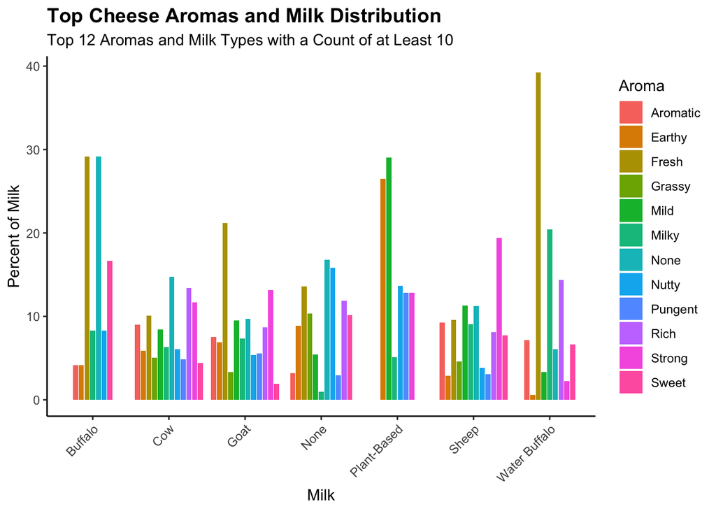

```r
top_aroma_df = df |>
  left_join(cheese_df, by = join_by(cheese_id)) |>
  left_join(aroma_df, by = join_by(aroma_id)) |>
  group_by(aroma, aroma_id) |>
  summarise(cnt = n(), .groups = 'keep') |>
  arrange(desc(cnt)) |>
  head(12)

df |>
  select(cheese_id, milk_id, aroma_id) |>
  left_join(cheese_df, by = join_by(cheese_id)) |>
  inner_join(top_aroma_df, by = join_by(aroma_id)) |>
  inner_join(milk_cnt_df, by = join_by(milk_id)) |>
  mutate(
    aroma = str_to_title(aroma),
    milk = str_to_title(milk)
    ) |>
  group_by(milk) |>
  mutate(y= n()) |>
  group_by(milk, aroma) |>
  mutate(x = n()) |>
  mutate(Unique_Cheese_Prct =  (x / y)*100) |>
  select(milk, aroma, Unique_Cheese_Prct, x, milk_cnt, y) |>
  distinct() |>
  ggplot(aes(x = milk, y = Unique_Cheese_Prct, fill = aroma)) +
  geom_col(position = position_dodge2(width = 0.3, preserve = "single")) +
  labs(
    title = "Top Cheese Aromas and Milk Distribution",
    subtitle = 'Top 12 Aromas and Milk Types with a Count of at Least 10',
    x = "Milk",
    y = "Percent of Milk",
    fill = 'Aroma'
  ) +
  theme_classic() +
  theme(
    axis.text.x = element_text(angle = 45, vjust = 1, hjust=1),
    plot.title = element_text(size = 14, face = "bold"))
```

# **Exporting Processed Data**

```r
# Export cleaned Emissions dataset
write.csv(yearly_emissions_by_area, "yearly_emissions_by_area_cleaned.csv", row.names = FALSE)
write.csv(yearly_emissions, "yearly_emissions_cleaned.csv", row.names = FALSE)
write.csv(emissions_by_area, "emissions_by_area_cleaned.csv", row.names = FALSE)

# Export cleaned DART water permit dataset
write.csv(tbl1_permit_lvl, "tbl1_permit_lvl_cleaned.csv", row.names = FALSE)
write.csv(tbl2_permit_act_lvl, "tbl2_permit_act_lvl_cleaned.csv", row.names = FALSE)
write.csv(tbl3_facility_lvl, "tbl3_facility_lvl_cleaned.csv", row.names = FALSE)
write.csv(tbl4_app_lvl, "tbl4_app_lvl_cleaned.csv", row.names = FALSE)

# Export cleaned Cheese Quality dataset
write.csv(cheese_df, "cheese_df_cleaned.csv", row.names = FALSE)
write.csv(country_df, "country_df_cleaned.csv", row.names = FALSE)
write.csv(milk_df, "milk_df_cleaned.csv", row.names = FALSE)
write.csv(texture_df, "texture_df_cleaned.csv", row.names = FALSE)
write.csv(aroma_df, "aroma_df_cleaned.csv", row.names = FALSE)
write.csv(flavor_df, "flavor_df_cleaned.csv", row.names = FALSE)
write.csv(df, "final_cheese_data_cleaned.csv", row.names = FALSE)

# Confirm that the files were saved successfully
list.files(pattern = "*.csv")
```

```
##  [1] "aroma_df_cleaned.csv"
##  [2] "cheese_df_cleaned.csv"
##  [3] "country_df_cleaned.csv"
##  [4] "dart_2020_2025.csv"
##  [5] "dart_3.7.2025.csv"
##  [6] "DATA607_Project2Data_cheeses.csv"
##  [7] "emissions_by_area_cleaned.csv"
##  [8] "final_cheese_data_cleaned.csv"
##  [9] "flavor_df_cleaned.csv"
## [10] "milk_df_cleaned.csv"
## [11] "project2-emissions-data.csv"
## [12] "tbl1_permit_lvl_cleaned.csv"
## [13] "tbl2_permit_act_lvl_cleaned.csv"
## [14] "tbl3_facility_lvl_cleaned.csv"
## [15] "tbl4_app_lvl_cleaned.csv"
## [16] "texture_df_cleaned.csv"
## [17] "yearly_emissions_by_area_cleaned.csv"
## [18] "yearly_emissions_cleaned.csv"
```

### **Why Exporting Matters?**

- **Preserving Cleaning Efforts:** Once data transformation is complete, saving the cleaned versions prevents the need to redo preprocessing each time.
- **Improving Reproducibility:** The structured datasets can be shared with other analysts or data scientists for further analysis.
- **Facilitating Advanced Analytics:** The exported `.csv` files are now ready for machine learning models, visualization dashboards, and predictive analytics.

# **Conclusion**

This project focused on transforming and analyzing three diverse datasets, demonstrating the importance of data wrangling techniques in preparing raw information for meaningful insights. By leveraging `tidyr` and `dplyr`, we efficiently cleaned, structured, and transformed the datasets into a tidy format, making them suitable for downstream analysis.

### **Overall Insights and Future Applications:**

- **Data Preparation Matters:**

The process of tidying and transforming data is crucial for accurate and meaningful analysis. Well-structured data improves efficiency in both visualization and modeling.

- **Standardization & Normalization:**

Converting datasets to tidy formats ensured that values were easily accessible for statistical computation.

- **Potential for Further Analysis:**

These datasets can now be used for deeper predictive modeling, trend forecasting, and policy recommendations based on their respective domains.

Through this project, we reinforced the significance of data wrangling techniques in real-world data science applications. The ability to tidy, transform, and analyze raw data is a fundamental skill that enhances decision-making and unlocks valuable insights across different industries.